Consider the following dataset

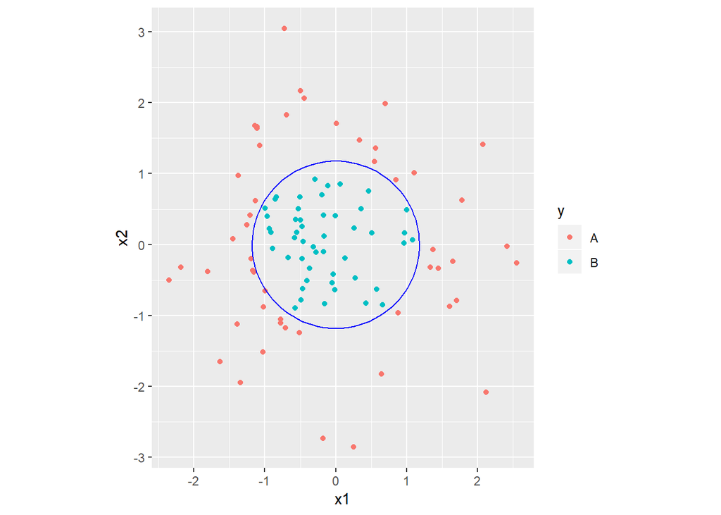

```r
LibraryList<-c("tidyverse", "tidymodels", "ggplot2", "tree","randomForest","gbm","modelr")
for (TheLibrary in LibraryList)
{
  if(TheLibrary %in% rownames(installed.packages()) == FALSE) install.packages(TheLibrary)
}

library(tidyverse)
library(tidymodels)
library(ggplot2)
library(tree)
library(randomForest)
library(gbm)
library(modelr)
set.seed(1234)
somedata <- tibble(
    x1 = rnorm(100),
    x2 = rnorm(100)
) %>% mutate(y = as_factor(ifelse(x1^2 + x2^2 > 1.39, "A", "B")))
circlepts <- tibble(theta = seq(0, 2*pi, length = 100)) %>%
    mutate(x = sqrt(1.39) * sin(theta), y = sqrt(1.39) * cos(theta))

somedata<-data.frame(somedata)

p <- ggplot(somedata) + geom_point(aes(x1, x2, color = y)) + coord_fixed() +
    geom_polygon(data = circlepts, aes(x, y), color = "blue", fill = NA)
p
```

1. Fit a classification tree model to the observations. And overlay the decision boundaries of the predictions on top of the plot above.

You could use predict() function over a dense grid and then use `p + geom_contour(....)`.

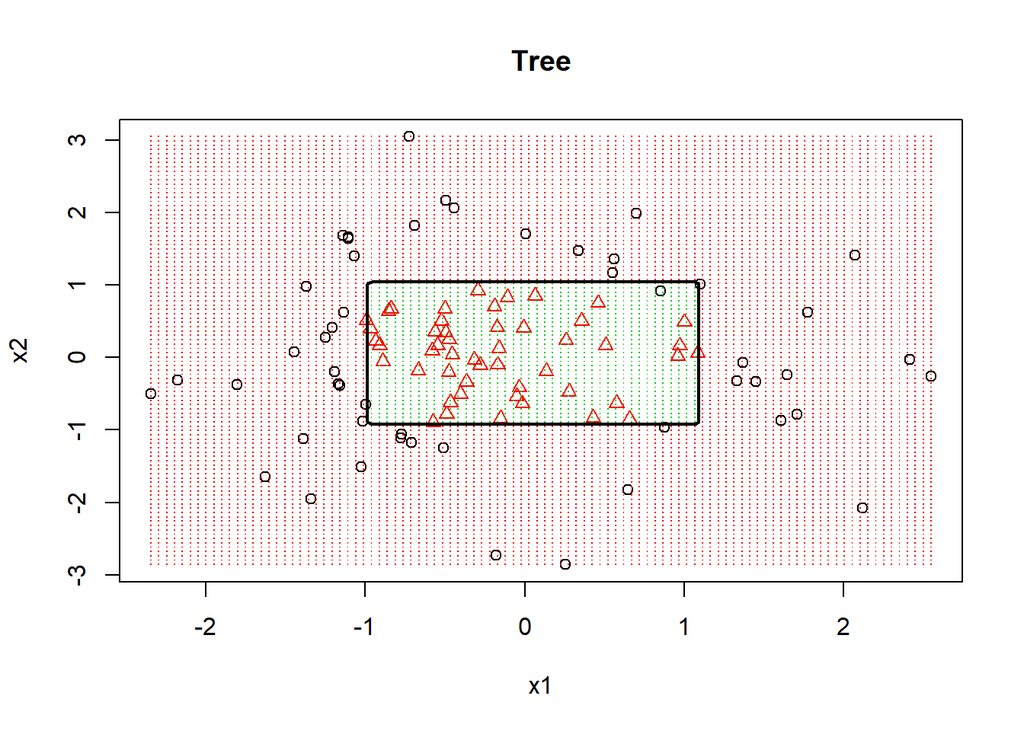

```r
# https://michael.hahsler.net/SMU/EMIS7332/R/viz_classifier.html
# R Code for Comparing Decision Boundaries of Different Classifiers
# Really good function for plotting decision boundaries. Works for:
# kNN, naiveBayes, LDA, logistic regression, trees, RFs, SVMs, NNs

##  HOWEVER -- the example uses the rpart package rather than the tree package,
## which can produce different results -- forunately it should not be an
## issue since this function is generally applicable
## 04-27-2019
## I altered the function a little to check if the response is a factor variable
## and converted it to numeric - doesn't work otherwise.
## however, these plots will only work with 2 predictors. The response
## can have multiple categories.
## added check for 'package' - different packages need additional args to predict values
decisionplot <- function(model, data, class = NULL, predict_type = "class",
  resolution = 100, showgrid = TRUE, package = NULL, numTrees = NULL, ...) {

  #
  # if(!is.null(class)) {
  #     if (is.factor(data[,class])) cl<-as.numeric(levels(data[,class]))[data[,class]] else cl <- data[,class]
  #   }else {
  #     cl <- 1
  #   }
  #data<-data[, -which(names(data) == responseVar)]
  if(!is.null(class)) cl <- data[,class] else cl <- 1

  data <- data[,1:2]
  k <- length(unique(cl))


  # plot(data, col = as.integer(cl)+1L, pch = as.integer(cl)+1L, ...)
  plot(data, col = as.integer(cl), pch = as.integer(cl), ...)

  # make grid
  r <- sapply(data, range, na.rm = TRUE)
  xs <- seq(r[1,1], r[2,1], length.out = resolution)
  ys <- seq(r[1,2], r[2,2], length.out = resolution)
  g <- cbind(rep(xs, each=resolution), rep(ys, time = resolution))
  colnames(g) <- colnames(r)
  g <- as.data.frame(g)

  ### guess how to get class labels from predict
  ### (unfortunately not very consistent between models)

  if(!is.null(package)){
    if (package == "gbm") p <- predict(model, newdata=g, n.trees=numTrees)
    } else {
      p <- predict(model, g, type = predict_type)
    }

  if(is.list(p)) p <- p$class
  p <- as.factor(p)

  if(showgrid) points(g, col = as.integer(p)+1L, pch = ".")

  z <- matrix(as.integer(p), nrow = resolution, byrow = TRUE)
  contour(xs, ys, z, add = TRUE, drawlabels = FALSE,
    lwd = 2, levels = (1:(k-1))+.5)

  invisible(z)
}
tree_fit <- tree(y ~ ., somedata)
#tree_pred <- predict(tree_fit, somedata, n.trees=1000)
#predict()
#p + geom_contour()

decisionplot(tree_fit, somedata, class="y", main = "Tree")
```

2. Repeat it with random forest.

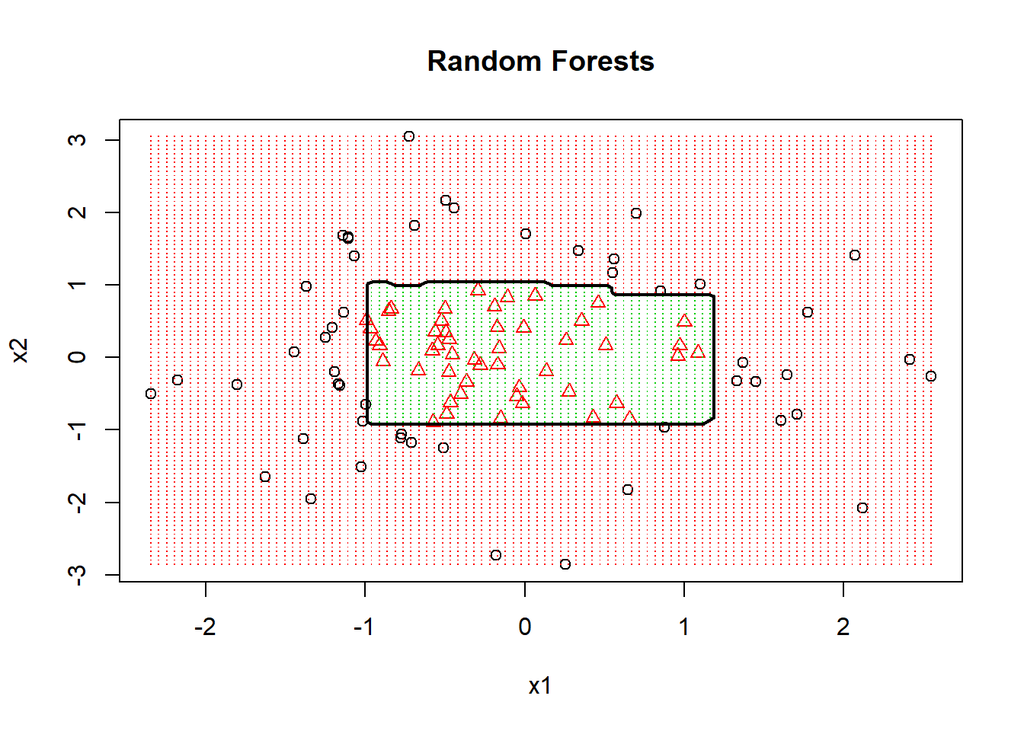

```r
rf_fit <- randomForest(y~., somedata, mtry = 2, importance = TRUE)
decisionplot(rf_fit, somedata, class="y", main = "Random Forests")
```

3. Repeat again using boosting.

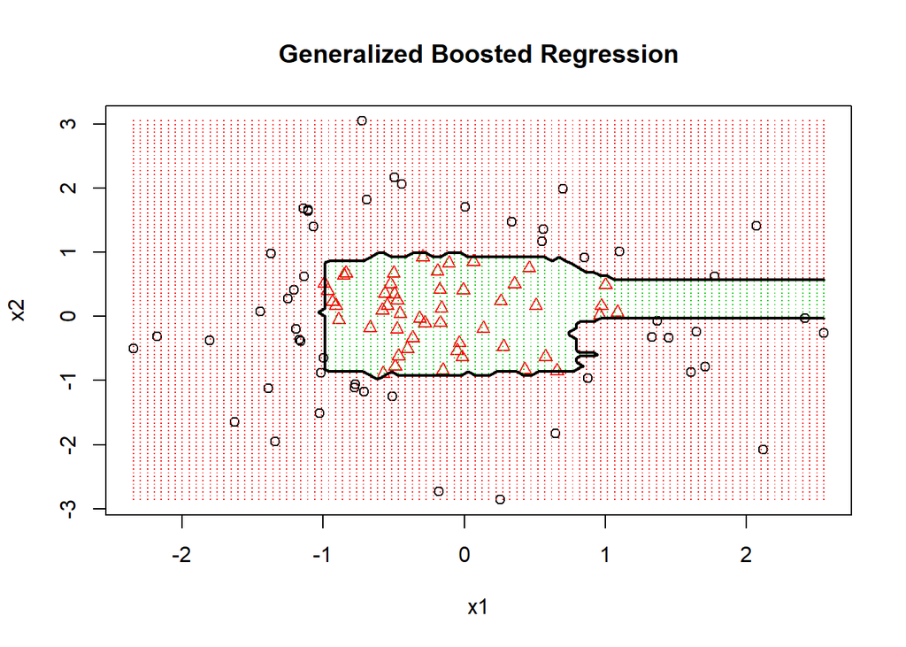

```r
#levels(somedata$y)[levels(somedata$y)=="A"]<-0
#levels(somedata$y)[levels(somedata$y)=="B"]<-1

## Function altered and added to work with gbm - will incorporate it to previous function later.
boostDecisionPlot<-function(model,data, class=NULL,numTrees, resolution=100,showgrid=TRUE,...) {

  if(!is.null(class)) cl <- data[,class] else cl <- 1

  CNames<-unique(data[,class])
  data <- data[,1:2]

  plot(data, col = as.integer(cl), pch = as.integer(cl), ...)


  k <- length(unique(cl))
  # make grid
  r <- sapply(data, range, na.rm = TRUE)
  xs <- seq(r[1,1], r[2,1], length.out = resolution)
  ys <- seq(r[1,2], r[2,2], length.out = resolution)
  g <- cbind(rep(xs, each=resolution), rep(ys, time = resolution))
  colnames(g) <- colnames(r)
  g <- as.data.frame(g)
  pred <- predict.gbm(model, newdata=g,type="response", n.trees=numTrees)
  pred<-data.frame(pred)
  colnames(pred)<-CNames

  p <- as.factor(colnames(pred)[1:2][apply(pred[, 1:2], 1, which.max)])

  if(showgrid) points(g, col = as.integer(p)+1L, pch = ".")

  z <- matrix(as.integer(p), nrow = resolution, byrow = TRUE)
  contour(xs, ys, z, add = TRUE, drawlabels = FALSE,
    lwd = 2, levels = (1:(k-1))+.5)

  invisible(z)
  # return(g)
}

boosting_fit=gbm(y ~.,data=somedata, distribution="multinomial", n.trees=1000)
boostDecisionPlot(model=boosting_fit, data=somedata,class="y",numTrees=1000, main="Generalized Boosted Regression")
```

4. Comment on the shapes of the decision boundaries.

For all models except boosted I chose default settings. The GBM package automatically selects a bernoulli distribution when one is not specified. Since the data are fitting a response to a categorical variable, I selected a multinomial distribution to better represent the data. Otherwise, Boosted seemed to be the most overfit, with some inaccurate predictions for high x1 values and x2 values of 0. The classic tree fit was the most general and rectangular in shape and random forests were inbetween but closer in resemblance to the tree. Random forests seems to have fewer classification errors than the classic tree because it is more closely fit to the input data. Based on the output, I would assume random forests would potentially perform the best overall with new data and boosted to perform the worst.